[← Culture Voyager 목차](https://waterfirst.github.io/culture-voyager/)

# 교토 — 천년 고도의 미학

Culture Voyager | 이끼 정원, 대나무 숲, 게이샤 거리. 일본 미의식의 원형을 걷는다

Author

Nakcho Choi

Published

May 4, 2026

## 블랙홀 한 장면: 이끼 위의 빗방울

사이호지(西芳寺), 이른바 ‘코케데라(苔寺)’. 120종의 이끼가 덮은 정원.

빗방울이 이끼 위에 떨어지는 순간 — 그 소리를 들어본 적 있는가? 수백 년 된 이끼 융단이 빗물을 머금는 소리. 그건 소리가 아니라 **침묵이 스며드는 과정**이다.

무소 소세키(夢窓疎石)라는 14세기 선승이 이 정원을 설계했다. 그런데 설계라고 하기엔 어폐가 있다. 이건 “자연이 알아서 아름다워지도록 조건을 배치한 것”이니까. 정원사가 아니라 **시간에게 일을 시킨** 거다.

교토라는 도시 전체가 그렇다. 천 년 동안 수도였고, 천 년 동안 **아무것도 서두르지 않았다.** 그래서 이 도시를 걷는 건 단순한 여행이 아니라, 내 안의 속도를 재설정하는 일이다.

## 왜 교토인가: 미의식의 원형

### 와비사비(侘寂) — 불완전함의 아름다움

서양에서 아름다움이란 “완벽한 대칭”이다. 파르테논 신전, 베르사유 궁전. 하지만 교토가 말하는 아름다움은 정반대다.

금이 간 찻잔을 금으로 이어 더 아름답게 만드는 킨츠기(金繕い). 시간이 묻은 나무 기둥을 광을 내지 않고 그대로 두는 감각. **노화가 곧 성숙**이라는 미학.

이걸 몸으로 느끼려면 교토에 가야 한다. 책으로는 안 된다. 적어도 발바닥으로 자갈 깔린 참배길을 밟아봐야 안다.

### 사계절의 설계

교토 사람들은 “계절을 먹는다”고 말한다. 봄에는 벚꽃떡(사쿠라모치), 여름엔 유리처럼 투명한 와라비모치, 가을엔 단풍 모양 과자, 겨울엔 따뜻한 유도후.

풍경도 마찬가지다. **같은 장소를 네 번 가야 교토를 한 번 본 것**이다.

## 3일 추천 코스

### Day 1: 히가시야마 — 역사의 켜를 걷다

**아침**: 기요미즈데라(清水寺)에서 시작. 새벽 6시 개장이니 일찍 가자. 관광객이 밀려오기 전 청수의 무대(清水の舞台)에서 교토 시가지가 내려다보이는 순간 — 그게 이 도시와의 첫 인사다.

**오전**: 니넨자카 → 산넨자카 내려오기. 경사진 돌길 양편의 마치야(町家) 건물들. 100년 된 과자 가게에서 야츠하시(八ツ橋) 하나 집어먹으며.

**점심**: 니시키 시장(錦市場). ’교토의 부엌’이라 불리는 400미터 아케이드. 다시마키 타마고(두꺼운 달걀말이), 하모(갯장어) 텐푸라, 두유 도넛. 한 끼가 아니라 열 끼를 조금씩.

**오후**: 철학의 길(哲学の道). 니시다 키타로 교수가 매일 걸으며 명상했다는 수로변 산책길. 봄이면 벚꽃이 수면에 떨어지고, 가을이면 단풍이 물 위를 흐른다.

**저녁**: 기온(祇園) 하나미코지도리. 운이 좋으면 마이코(무용수습생)가 지나가는 걸 볼 수 있다. 폰토초(先斗町) 골목에서 가모가와 강가를 보며 저녁.

### Day 2: 아라시야마 — 자연의 설계

**아침**: 대나무 숲(竹林の小径). 반드시 8시 이전에 도착할 것. 대나무 사이로 빛이 스며드는 시간. 바람이 대나무를 흔들면 그 소리가 일본 환경청이 선정한 ‘100대 소리 풍경’ 중 하나다.

**오전**: 텐류지(天龍寺) 정원. 무소 소세키가 설계한 또 하나의 걸작. 아라시야마 산을 배경으로 삼은 차경(借景) 기법 — 정원의 경계 너머 산까지 정원에 포함시키는 발상.

**점심**: 아라시야마 요시무라(嵐山よしむら)에서 소바. 도게츠교(渡月橋) 건너편에서 산 풍경을 보며.

**오후**: 사가노 토롯코 열차. 호즈강(保津川) 계곡을 따라 25분 달리는 관광열차. 창밖 풍경이 엽서 그 자체.

**저녁**: 교토역 근처 이자카야에서 오반자이(おばんざい, 교토 가정식). 두부, 절임채소, 삶은 유바(두부 껍데기) — 소박하지만 깊은 맛.

### Day 3: 후시미 & 남부 — 신비의 영역

**새벽**: 후시미 이나리 신사(伏見稲荷大社). 만 개의 주황색 도리이(鳥居). 무료, 24시간 개방. 정상까지 왕복 2시간. 새벽에 가면 거의 혼자 걸을 수 있다. 도리이 터널 사이로 새벽빛이 스며드는 순간 — **이건 종교가 아니라 조형예술**이다.

**오전**: 우지(宇治)로 이동. 뵤도인(平等院) — 10엔 동전 뒷면에 그려진 그 건물. 말차의 고장에서 진짜 말차 한 잔.

**오후**: 코케데라(苔寺) 방문 — 사전 예약 필수(엽서 또는 온라인). 3,000엔 입장료지만, 그 값어치를 한다. 사경(写経)부터 시작해서 정원 산책. 인원 제한 덕에 고요함이 보장된다.

## 교토 여행 지도: 3일 궤적

3일간의 동선을 지도 위에 표시했다. 각 핀을 클릭하면 명소 정보를 볼 수 있다.

[interactive chart not shown]

**핵심 명소 좌표**

**Day 1 — 히가시야마**

- 기요미즈데라 (清水寺): 34.9948°N, 135.7850°E — 새벽 6시 개장, 청수의 무대에서 시가지 조망
- 니시키 시장 (錦市場): 35.0050°N, 135.7644°E — 400m 아케이드, 교토의 부엌
- 철학의 길 (哲学の道): 35.0228°N, 135.7941°E — 벚꽃/단풍 수로변 산책길 2km
- 기온 하나미코지 (祇園): 35.0037°N, 135.7755°E — 마이코 거리, 폰토초 저녁

**Day 2 — 아라시야마**

- 대나무 숲 (竹林の小径): 35.0170°N, 135.6713°E — 반드시 8시 이전 도착
- 텐류지 (天龍寺): 35.0154°N, 135.6745°E — 차경 정원의 걸작
- 도게츠교 (渡月橋): 35.0118°N, 135.6778°E — 아라시야마 상징

**Day 3 — 후시미 & 남부**

- 후시미 이나리 (伏見稲荷大社): 34.9671°N, 135.7727°E — 만 개의 도리이, 24시간 무료
- 뵤도인 (平等院): 34.8893°N, 135.8076°E — 10엔 동전의 건물, 우지 말차
- 코케데라 (苔寺): 35.0003°N, 135.6843°E — 사전 예약 필수, 120종 이끼 정원

## 먹어야 할 것들

교토의 맛은 “담백함의 극치”다. 화려하지 않지만 깊다.

- **유도후(湯豆腐)**: 난젠지 근처 ’오쿠탄(奥丹)’은 380년 역사. 두부를 다시마 국물에 데워 먹는 것 — 이게 뭐가 맛있냐고? 가보면 안다.
- **가이세키(懐石)**: 한 끼에 2~5만 원대부터. 계절 식재료로 코스를 짜는데, 접시 하나하나가 작품.
- **말차 디저트**: 나카무라 토키치(中村藤吉) 우지 본점. 말차 파르페의 원조.
- **니시키 시장 먹거리**: 다코타마고(문어 달걀말이), 아부리모치(구운 떡), 두유도넛.

## 교토 여행, 시즌별 풍경

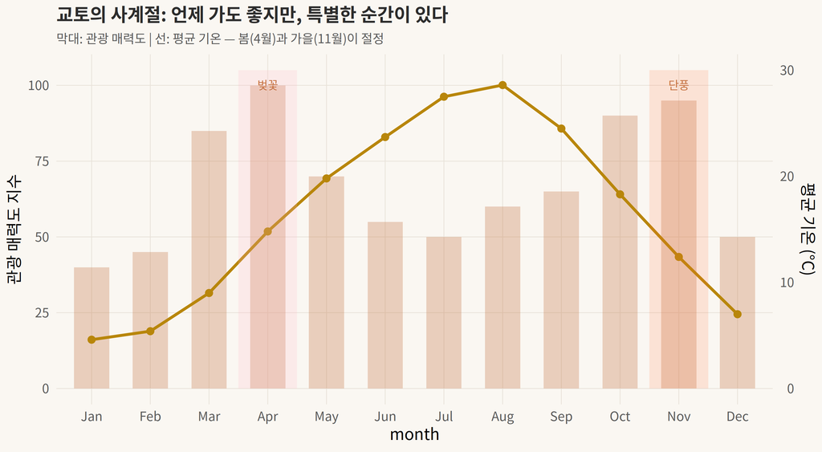

## 예산 가이드: 현실적으로 얼마?

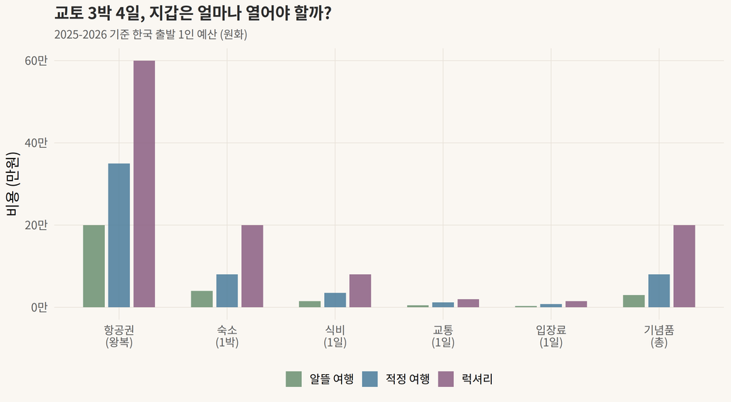

**예산 꿀팁**

- **알뜰 여행 (3박 4일 총 50~70만 원)**: 게스트하우스, 편의점+시장 먹거리, 버스 1일권(1,100엔), 무료 명소 중심
- **적정 여행 (3박 4일 총 100~130만 원)**: 비즈니스 호텔, 가이세키 1회 포함, 교통 패스
- **럭셔리 (3박 4일 총 200만 원~)**: 료칸, 가이세키 매일, 택시 이동, 프라이빗 투어

## 교토 명소별 추천 시간대

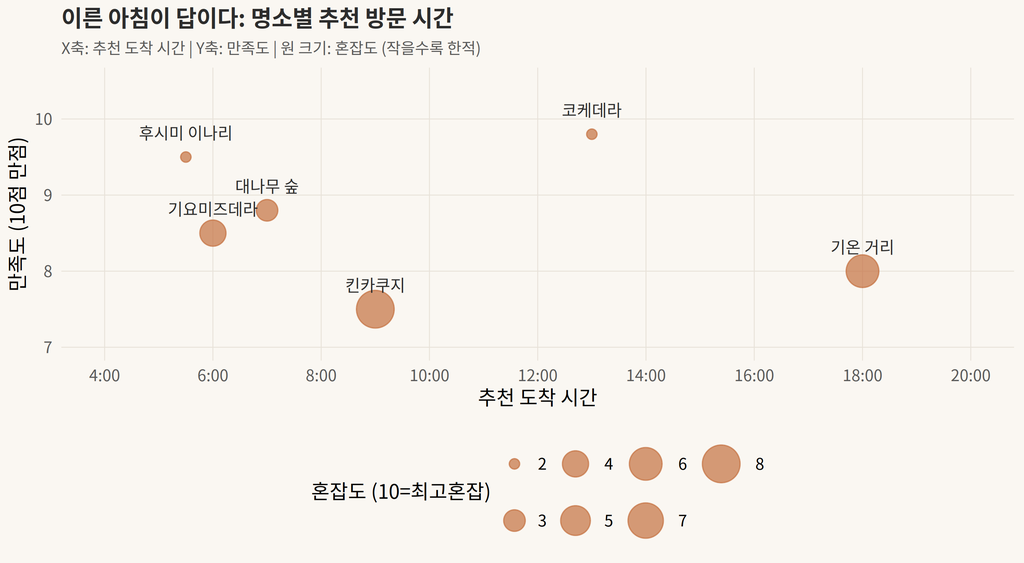

## 교토를 듣다: 추천 플레이리스트

교토를 걸을 때 어울리는 음악이 있다. 사카모토 류이치의 피아노, 하루오미 호소노의 앰비언트, 유키 카지우라의 선율.

[interactive chart not shown]

## 교토를 보다: 영상으로 미리 걷기

### 아라시야마 대나무 숲 — 새벽의 고요

[video not shown]

### 후시미 이나리 — 만 개의 도리이를 걷다

[video not shown]

## 교토가 가르쳐주는 것

여행지에서 “뭘 보느냐”보다 **“어떤 속도로 보느냐”**가 중요하다는 걸 교토에서 배운다.

서울에서 우리는 하루에 만 보를 걷지만 아무것도 보지 못한다. 교토에서는 백 보를 걸어도 세 가지를 발견한다. 이끼의 색이 바뀌는 것, 물이 흐르는 방향, 돌 하나의 배치.

일본인들은 이걸 **‘마(間)’**라고 부른다. 비어있는 공간, 침묵의 시간, 아무것도 하지 않는 순간 — 그게 오히려 가장 충만한 순간이라는 역설.

여행을 떠나기 전에 질문 하나만 던져보자:

> “내가 마지막으로 아무것도 하지 않으면서 충만했던 순간은 언제였을까?”

그 답이 떠오르지 않는다면 — 교토에 가야 할 이유가 하나 더 생긴 거다.

## 실전 팁 모음

**교토 여행 체크리스트**

- **교통**: 간사이공항 → 교토 하루카 특급 (75분, 3,640엔). 시내는 버스 1일권 (1,100엔)
- **예약 필수**: 코케데라(온라인 예약), 가이세키 레스토랑, 마이코 체험
- **현금 준비**: 작은 가게, 신사 입장료는 현금만 가능한 곳 많음
- **구글맵 오프라인**: 교토 지하 구간에서도 길 찾기 가능하도록
- **에티켓**: 대나무 숲에서 대나무 만지지 않기, 게이샤/마이코 사진 무단촬영 금지
- **최적 시기**: 벚꽃 3월 말~4월 초, 단풍 11월 중순~12월 초

*“여행은 도착하는 것이 아니라 걷는 것이다.”* — 그리고 교토는 **느리게 걷는 법**을 가르쳐주는 유일한 도시다.

*Culture Voyager — 주말마다 한 편의 이야기를 전합니다.* *다음 여행지는 어디일까요? 프라하의 카프카, 아이슬란드의 빙하가 기다리고 있습니다.*

[← Culture Voyager 목차로 돌아가기](https://waterfirst.github.io/culture-voyager/)